# LMM

# Linear Mixed Model

The predictor for this model is
$$\mathbb{E}\left[ y_{ij} \right] = \beta_0 + \beta_1 x_i + v_j$$
The model design matrix for the random effect has one row for each observation. The row of the design matrix associated with the $ij$-th observation consists of zeroes except for the element associated with $v_j$, which has a one.

##### *Simulate example data*

```r
library(inlabru)
library(INLA)
library(ggplot2)
library(dplyr)
```

```r
beta = c(1.5,1)
sd_error = 1
tau_group = 1

n = 100
n.groups = 5
x = rnorm(n)
v = rnorm(n.groups, sd = tau_group^{-1/2})
y = beta[1] + beta[2] * x + rnorm(n, sd = sd_error) +
  rep(v, each = 20)

df = data.frame(y = y, x = x, j = rep(1:5, each = 20))
```

Note that `inlabru` expects an integer indexing variable to label the groups.

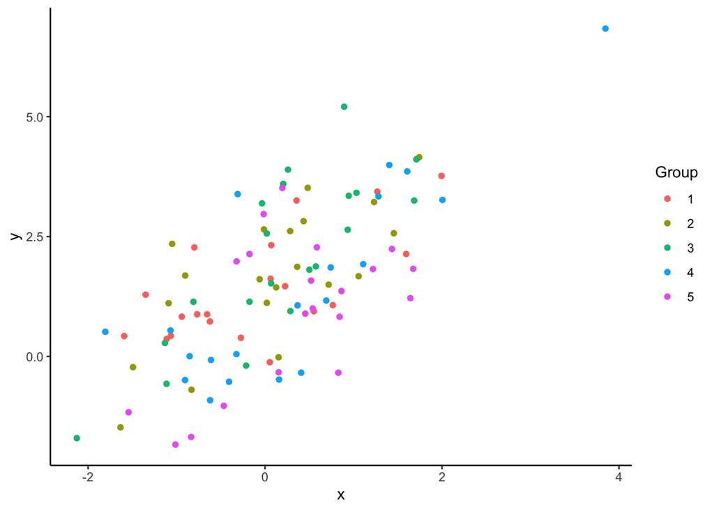

Data for the linear mixed model example with 5 groups

```r
df$jfac = as.factor(df$j)
ggplot(df) +
  geom_point(aes(x = x, colour = jfac, y = y)) +
  theme_classic() +
  scale_colour_discrete("Group")
```

#### *Define model components and likelihood*

```r
# Define model components
cmp =  ~ Intercept(1) + beta_1(x, model = "linear") +
  v(j, model = "iid")
```

The group variable is indexed by column `j` in the dataset. We have chosen to name this component `v()` to connect with the mathematical notation that we used above.

```r
# Construct likelihood
lik =  like(formula = y ~.,
            family = "gaussian",
            data = df)
```

##### *Fit the model*

The model can be fitted exactly as in the previous examples by using the `bru` function with the components and likelihood objects.

```r
fit = bru(cmp, lik)
summary(fit)
```

```
inlabru version: 2.12.0
INLA version: 25.05.26
Components:
Intercept: main = linear(1), group = exchangeable(1L), replicate = iid(1L), NULL
beta_1: main = linear(x), group = exchangeable(1L), replicate = iid(1L), NULL
v: main = iid(j), group = exchangeable(1L), replicate = iid(1L), NULL
Likelihoods:
  Family: 'gaussian'
    Tag: ''
    Data class: 'data.frame'
    Response class: 'numeric'
    Predictor: y ~ .
    Used components: effects[Intercept, beta_1, v], latent[]
Time used:
    Pre = 0.875, Running = 0.375, Post = 0.0399, Total = 1.29
Fixed effects:
           mean    sd 0.025quant 0.5quant 0.975quant  mode kld
Intercept 1.345 0.120      1.110    1.345      1.580 1.345   0
beta_1    1.091 0.116      0.864    1.091      1.319 1.091   0

Random effects:
  Name    Model
    v IID model

Model hyperparameters:
                                            mean       sd 0.025quant 0.5quant
Precision for the Gaussian observations     0.73 1.03e-01      0.545 7.24e-01
Precision for v                         21909.12 2.43e+04   1405.215 1.43e+04
                                        0.975quant     mode
Precision for the Gaussian observations   9.51e-01    0.713
Precision for v                           8.64e+04 3803.060

Deviance Information Criterion (DIC) ...............: 321.12
Deviance Information Criterion (DIC, saturated) ....: 105.15
Effective number of parameters .....................: 2.85

Watanabe-Akaike information criterion (WAIC) ...: 320.82
Effective number of parameters .................: 2.47

Marginal log-Likelihood:  -180.29
 is computed
Posterior summaries for the linear predictor and the fitted values are computed
(Posterior marginals needs also 'control.compute=list(return.marginals.predictor=TRUE)')
```